# sanity check: RSA pipeline results on simulated data

michael freund

4/28/2020

# intro

## parameters

# simulation 1: balanced design, high SNR

## matrices

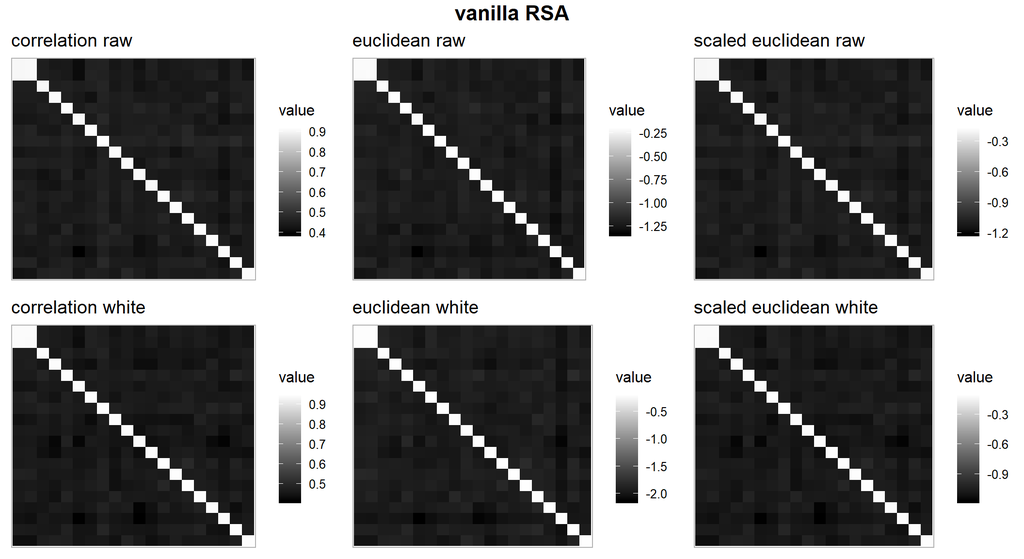

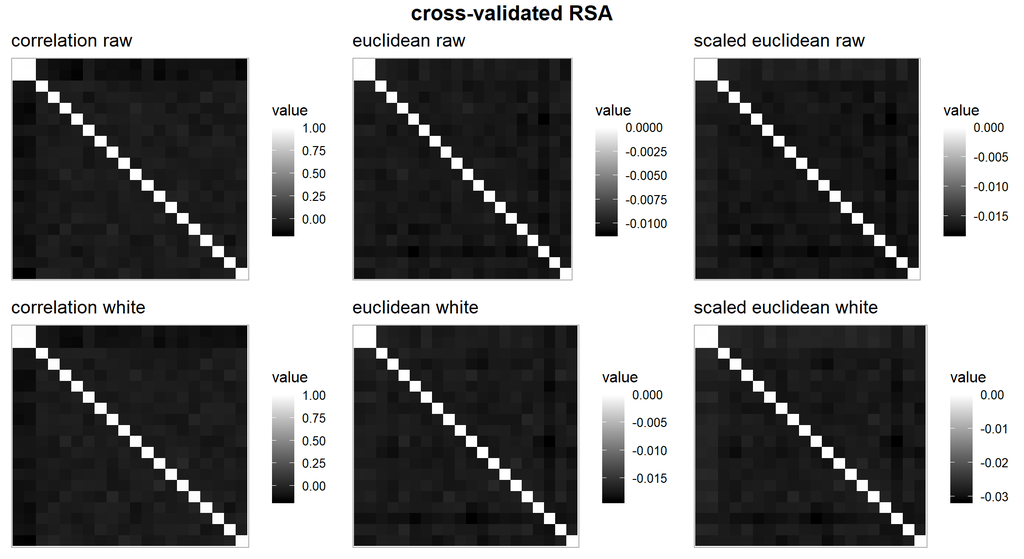

# simulation 2: balanced design, range of SNRs

## matrices

## RSA model fits (mean contrasts)

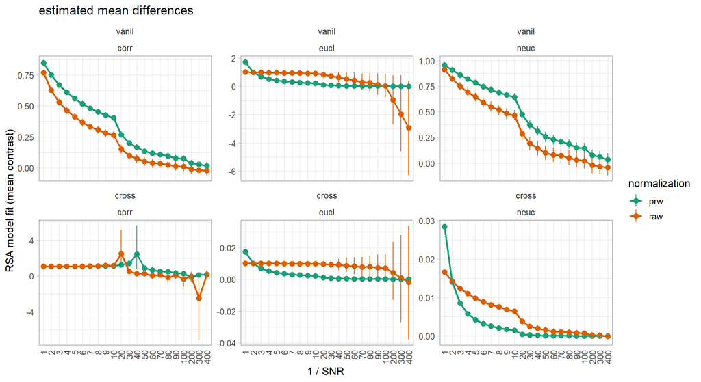

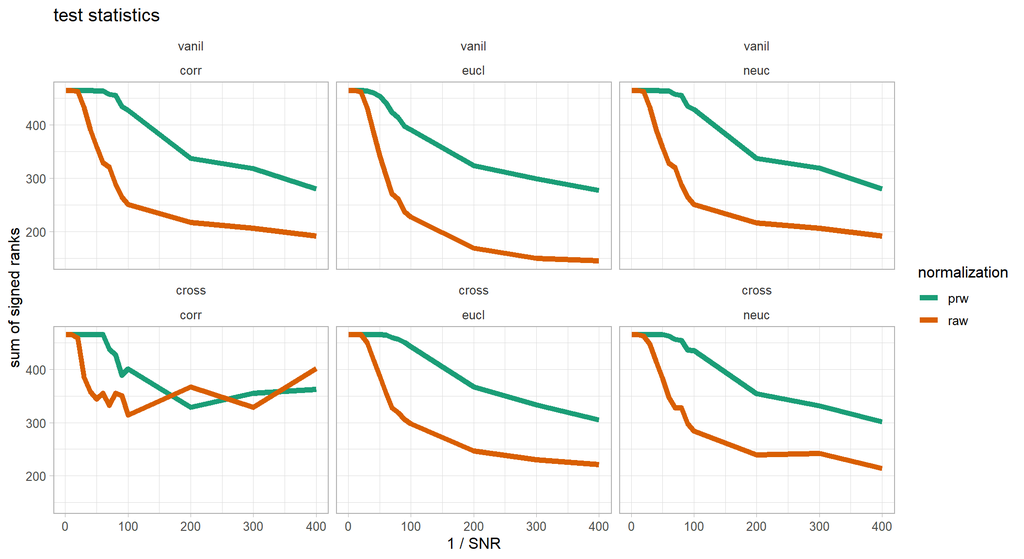

# simulation 3: unbalanced designs, range of SNR

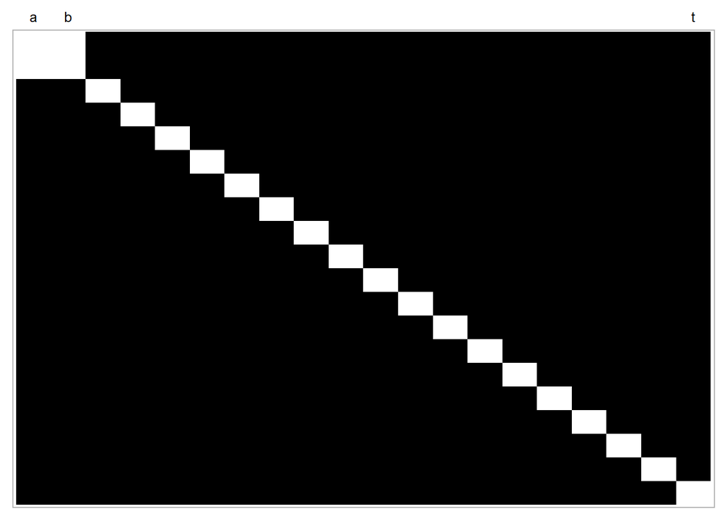

## matrices

## similarities (cell-wise means)

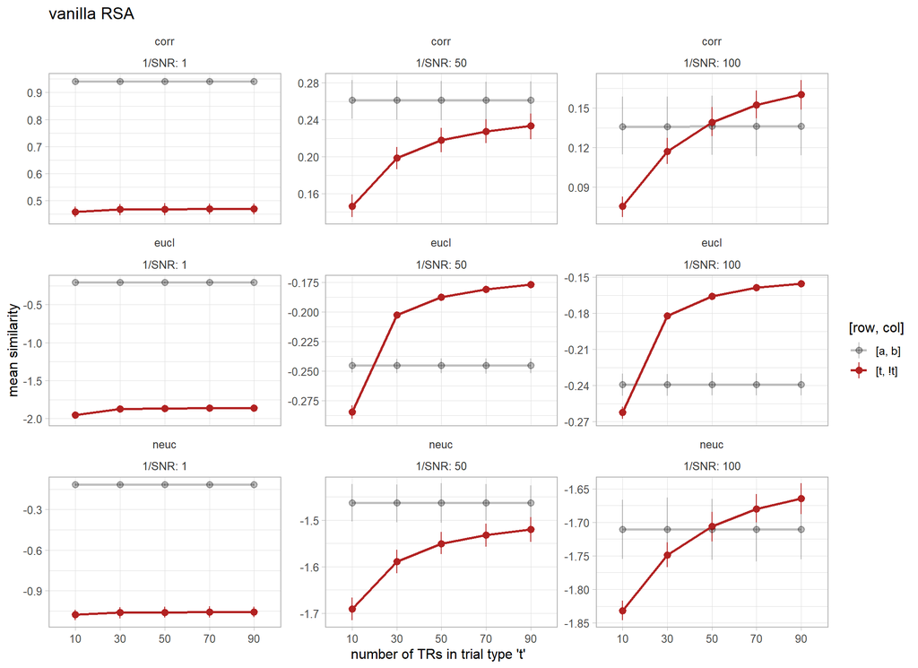

**notes**

- in high SNR scenarios (left panels), measurements are already close to their true values. I.e., correlation of trial types *a* and *b* are near 1; *t* and all other trial types (*!t*) are near 0.5.
- thus, in high SNR, the number of trials in *t* has little impact on similarity measures.
- because the ‘true’ correlation between *a* and *b* is 1, we can view the grey [*a*, *b*] line as the ‘noise ceiling’. I.e., the highest correlation observable, given the SNR, and the number of trials in *a* and *b* (here, 10).
- when decreasing SNR (moving right across panels), note that the y axis scale of the graphs decreases. I.e., with the correlation, the grey [*a*, *b*] line approaches zero. The noise ceiling is lowered.
- In lower SNR scenarios, the magnitude (mean) of the measures become much more sensitive to the number of trials within each trial type. This is seen as the increasing red [*t*, *!t*] line across the graphs. (note however that the variances of these measures, indicated by the error bars, remains relatively stable across different trial counts.)
- Eventually the observed [*t*, *!t*] similarity becomes greater than the [*a*, *b*] similarity, despite the true similarity being much less (e.g., r = 0.5 compared to r = 1). The key ingredients for this effect are:
  - relatively **low SNR** (low upper-bound on similarities)
  - a positive level of **“baseline” similarity**; i.e., trial types that are not predicted to be similar (because of theory) nevertheless evoke *somewhat* similar patterns (here, the baseline was r = 0.5)
  - **differing numbers of trials** between conditions of interest.
- under equivalent SNR scenarios, euclidean’s distance seems particularly sensitive to trial counts relative to correlation-like measures (correlation, standardized euclidean). not sure what to make of this, but interesting to note.

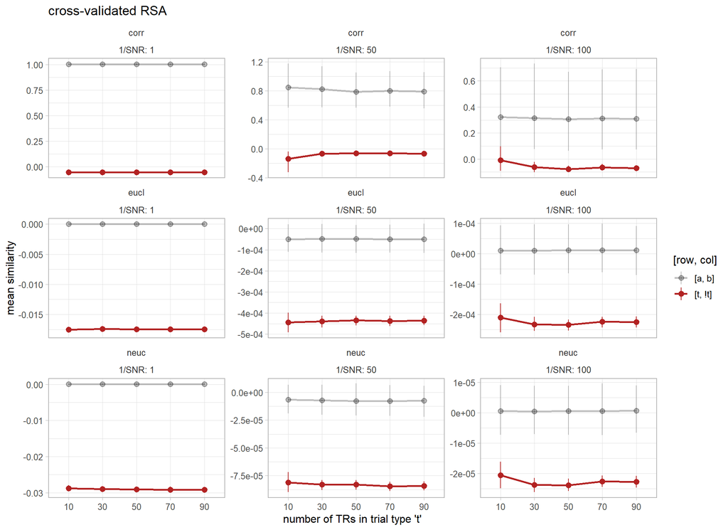

**notes**

- *note that the “cross-validated correlation” results here are not very interpretable: all cells with undefined correlations (as a result of variances $\leq 0$) were replaced with 0.* **focus instead on euclidean and standardized euclidean to interpret results**
- the picture is different with cross-validated measures
- first thing to note is that the SNR / number of trials does not impact the expected value of the similarity measure. For example, the ‘noise ceiling’ correlations ([*a*, *b*]) are roughly centered on zero (identical) in the euclidean distance and the standardized euclidean for all plots.
- what number of trials *does* impact is the variances. this can be seen as increasing error bars from left to right across panels (with SNR decreasing), or as decreasing error bars of the red [*t*, *!t*] lines within each plot (with trial counts increasing).
- also note that SNR impacts the *scale* of each plot. I.e., although identical patterns are centered at zero (grey line) across the board, patterns with r = 0.5 (red line) are located increasingly nearer to zero with decreasing SNR (red line approaches grey line from L to R panels). In other words, the only absolutely meaningful value in these measures is zero. the ratio of measures is defined by the SNR.
  - this may be imprtant to note: different subjects, brain regions may have different levels of SNR. Thus, some form of rescaling may be warranted prior to group analysis or comparing across regions.
  - what to use as the proper rescaling parameter? this question leads to complexities.
    - e.g., say we use the estimated variability within each subject’s RDM (e.g., across-cell SD). this estimate would be inflated because poorer SNRs are not only associated with smaller ratio scale, but *larger* variance. thus, subjects with lower SNR would be unfairly downweighted.

# conclusions